# Google Trends no R

Andreza Palma

20/09/2020

O **Google Trends** é uma ferramenta do google que mostra o volume de pesquisa de determinadas palavras em relação ao total de pesquisa.

O resultado é um índice de 0 a 100 e quanto mais próximo de 100, maior o interesse pela palavra.

Como forma de proteção, as pessoas ficaram mais em seus lares, assim, itens que proporcionam mais conforto foram mais consumidos:

1. pijamas
2. moleton
3. roupa de cama
4. pantufas

As seguintes bibliotecas são usadas neste estudo:

1. gtrendsR
2. tidyverse (especificamente ggplot2 e dplyr)

```r
#################### Carregar pacotes ####################
if(!require(gtrendsR))
  install.packages("gtrendsR")
library(gtrendsR)

if(!require(dplyr))
  install.packages("dplyr")
library(dplyr)

if(!require(ggplot2))
  install.packages("ggplot2")
library(ggplot2)

if(!require(patchwork))
  install.packages("patchwork")
library(patchwork)
```

Cabe notar que existem **3 elementos essenciais** para a função gtrends:

1. palavra ou frase de interesse (keyword)
2. região de interesse (geo)
3. período de tempo de interesse

Vamos procurar primeiro pelas buscas por seguro-desempregro no Brasil. Vejamos através do exemplo abaixo. Note que, de acordo com a explicação acima, precisamos definir a palavra buscada (seguro-desemprego), a região de interesse, no caso, Brasil (geo=c(“BR”)) e o período desejado (nesse caso, queremos todo o período disponível - time = ‘all’).

```r
segurodesemprego <- gtrends(c("seguro-desemprego"), geo = c("BR"), time = "all")
```

Podemos plotar diretamente os resultados usando a função plot:

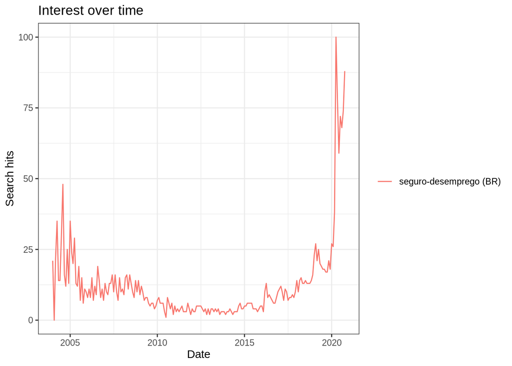

```r
plot(segurodesemprego)
```

Agora, vamos fazer o mesmo gráfico usando ggplot.

[figure not shown]

```r
time_trend=segurodesemprego$interest_over_time
plot<-ggplot(data=time_trend, aes(x=date, y=hits,group=keyword,col=keyword))+
        geom_line()+xlab('Time')+ylab('Interesse relativo')+ theme_bw()+
        theme(legend.title = element_blank(),legend.position="bottom",legend.text=element_text(size=12))+ggtitle("Volume de Busca no Google")
plot
```

Como podemos notar, a busca pela palavra seguro-desemprego deu um salto no período recente. Poderíamos limitar a nossa busca somente ao ano de 2020. Basta mudar time = all para time “2020-01-01 2020-06-14” Vejamos.

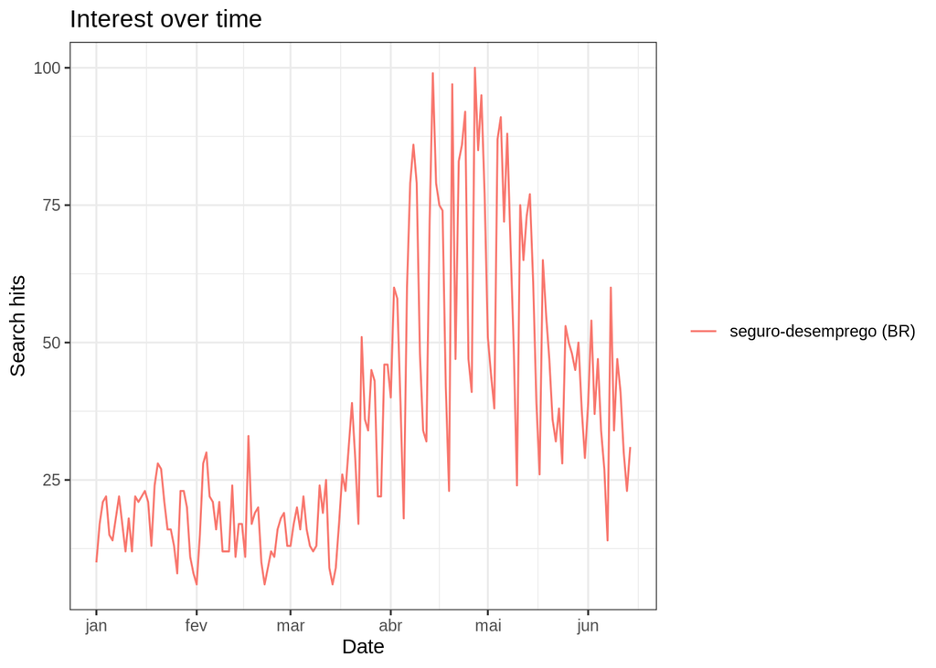

```r
segurodesemprego2 <- gtrends(c("seguro-desemprego"), geo = c("BR"), time = "2020-01-01 2020-06-14")
plot(segurodesemprego2)
```

E podemos comparar com o mesmo período do ano passado:

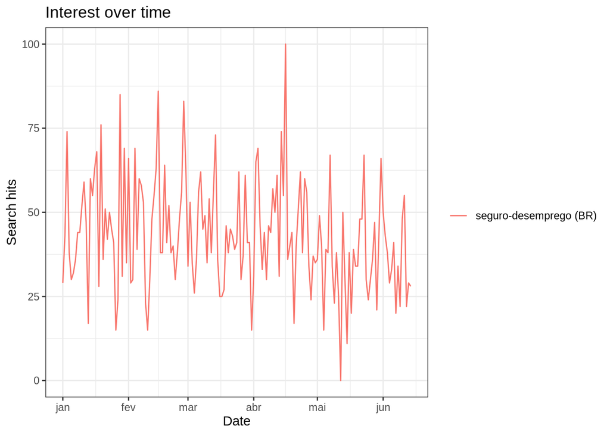

```r
segurodesemprego3 <- gtrends(c("seguro-desemprego"), geo = c("BR"), time = "2019-01-01 2019-06-14")
plot(segurodesemprego3)
```

Vamos verificar agora as buscas pela palavra coronavirus no Brasil e fazer o gráfico.

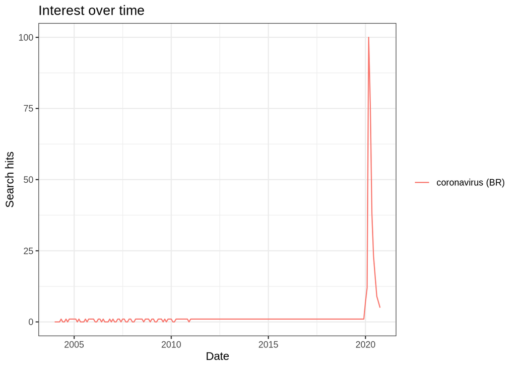

```r
corona <- gtrends("coronavirus",
                geo = "BR",
                time = "all")
plot(corona)
```

Vamos agora pesquisar um conjunto de palavras: coronavirus e hidroxicloroquina;

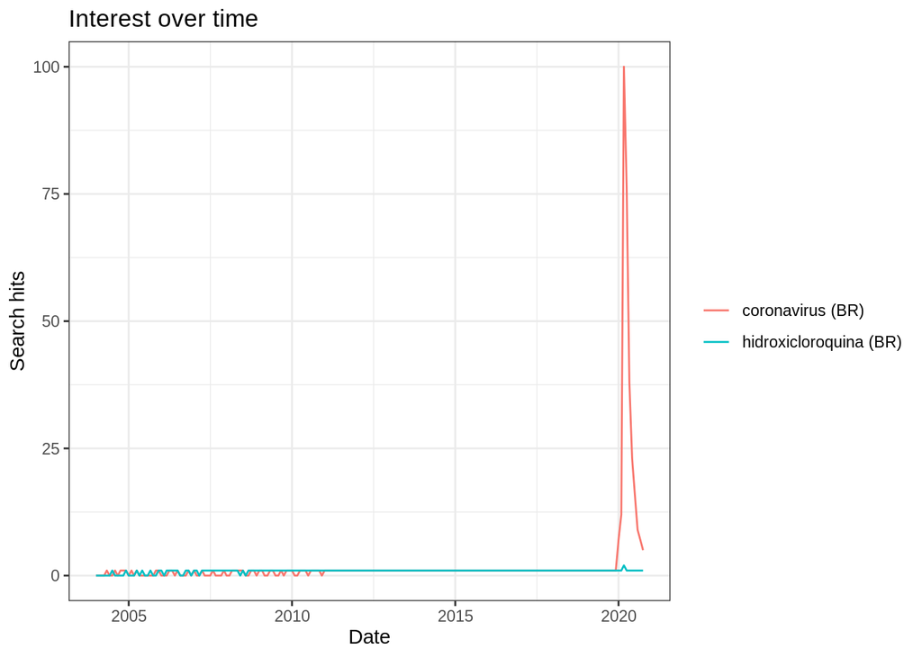

```r
corona2 =  gtrends(c("coronavirus", "hidroxicloroquina"), geo = c("BR"), time = 'all')
plot(corona2)
```

Feito de outra forma, acrescentando a palavra ivermectina a nossa busca e restringindo o período para a partir de 2015:

```r
#definindo as palavras que serão buscadas
keywords=c("Coronavirus","hidroxicloroquina","ivermectina")
#REgião geográfica: Brasil
country=c('BR')
#Escolhendo o período de tempo:
time=("2015-01-01 2020-06-14")

trends = gtrends(keywords, geo=country, time = time )
#selecionando apenas a colula com o interesse ao longo do tempo
time_trend=trends$interest_over_time
#para ver as 6 primeiras linhas, usamos head()
head(time_trend)
```

```
##         date hits     keyword geo                  time gprop category
## 1 2015-01-01   <1 Coronavirus  BR 2015-01-01 2020-06-14   web        0
## 2 2015-02-01   <1 Coronavirus  BR 2015-01-01 2020-06-14   web        0
## 3 2015-03-01   <1 Coronavirus  BR 2015-01-01 2020-06-14   web        0
## 4 2015-04-01   <1 Coronavirus  BR 2015-01-01 2020-06-14   web        0
## 5 2015-05-01   <1 Coronavirus  BR 2015-01-01 2020-06-14   web        0
## 6 2015-06-01   <1 Coronavirus  BR 2015-01-01 2020-06-14   web        0
```

Gráfico:

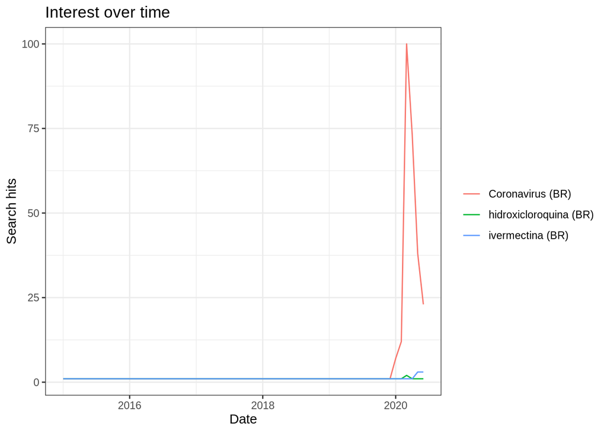

```r
 plot(trends)
```

Existem várias outras funcionalidades que você deve explorar no pacote gtrendsR. Por exemplo, podemos buscar as palavras nas últimas horas usando time = “now 4-H”:

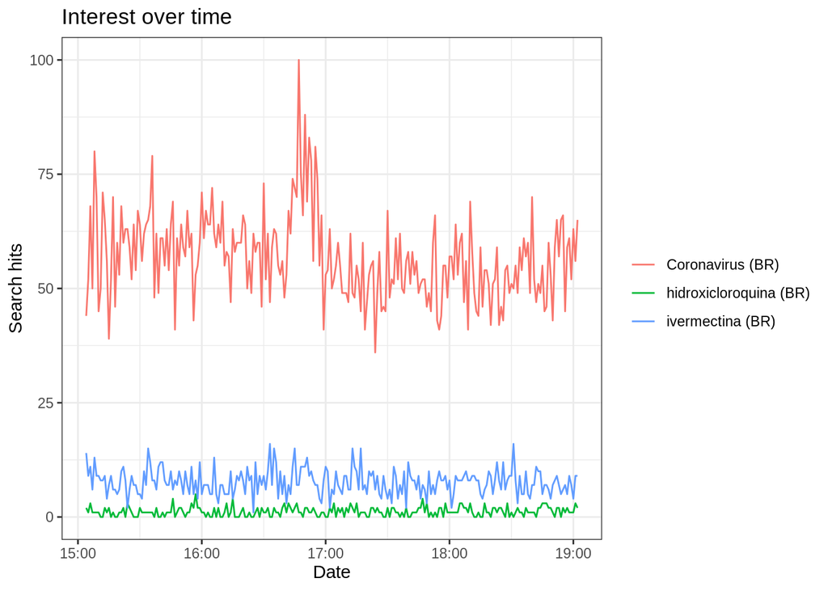

```r
trends2 = gtrends(keywords, geo=country, time = "now 4-H"  )
plot(trends2)
```

Abaixo algumas opções para time:

- Code Período de tempo;
- now 1-H última hora;
- now 4-H últimas quatro horas;
- now 1-d último dia;
- today 1-m 30 dias;
- today 3-m 90 dias;
- today 12-m últimos 12 meses;
- today+5-y ultimo 5 anos (default);
- all desde o início do google trends (2004);
- Y-m-d Y-m-d período entre as datas (ex.: “2010-01-01 2020-04-03”)

Vamos procurar agora pelas buscas por bitcoin:

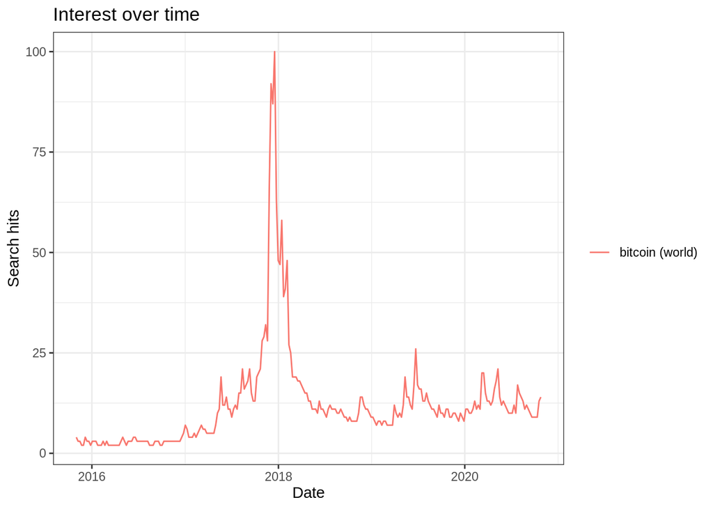

```r
 trends = gtrends(c("bitcoin"))
 plot(trends)
```

Acho que já ficou bastante claro como funciona gtrendsR e a grande variedade de informação que pode nos proporcionar.

Vamos agora fazer coisas um pouco mais complicadas. Para isso vamos instalar e carregar o pacote **patchwork** que permite manipular vários gráficos.

```r
#install.packages("patchwork")
#library(patchwork)
```

Vamos fazer uma busca por algumas palavras durante a pandemia no google trends. Para isso, vamos criar uma função (adaptada do Michael, do Casual inference), que vai facilitar a elaboração dos nossos gráficos. Essa função será plot_trend, com o argumento keyword_string. Vejamos abaixo.

```r
#função adaptada de Michael - Casual Inference
#função para plotar os gráficos a partir de gtrends, para o período de janeiro de 2020 a junho de 2020.
#nós vamos inserir uma linha vertical próximo a data de início da "quarentena", usando geom_vline no dia 10 de março de 2020.
plot_trend<-function(keyword_string){
data<-gtrends(c(keyword_string), time= "2020-01-01 2020-06-14", geo = "BR")
time_trend<-data$interest_over_time %>%
  mutate(hits=ifelse(hits=="<1",0.5,hits),
         date=as.Date(date),
         keyword=factor(keyword, levels = keyword_string))
plot<-ggplot(data=time_trend, aes(x=date, y=as.numeric(hits), colour=keyword)) +
  geom_line() +
  geom_vline(xintercept = as.numeric(as.Date("2020-03-10"))) +
  theme_bw() +
  scale_y_continuous(breaks = NULL) +
  theme(legend.position = "bottom",
        legend.title = element_blank(),
        legend.text=element_text(size=10),
        axis.title.x=element_blank(),
        axis.title.y=element_blank())
return(plot)
}
```

A função acima irá nos ajudar a fazer os gráficos mais rapidamente. Vamos procurar os termos “como cortar o cabelo”, como fazer pão, como fazer café e treino em casa, a fim de verificar se houve alguma mudança nas buscas a partir da pandemia.

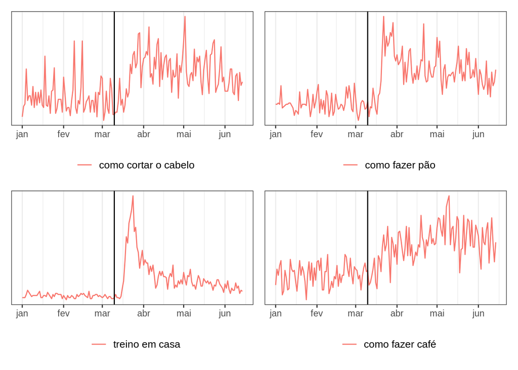

```r
cabelo_plot<-plot_trend(keyword_string = c( "como cortar o cabelo"))
comida_plot<-plot_trend(keyword_string = c("como fazer pão"))
fitness_plot<-plot_trend(keyword_string = c("treino em casa"))
coffee_plot<-plot_trend(keyword_string = c("como fazer café"))

(cabelo_plot + comida_plot) / (fitness_plot + coffee_plot)
```

Os esportes também foram afetados. Então vamos ver como estão as buscas pelos times Palmeiras e Corinthians.

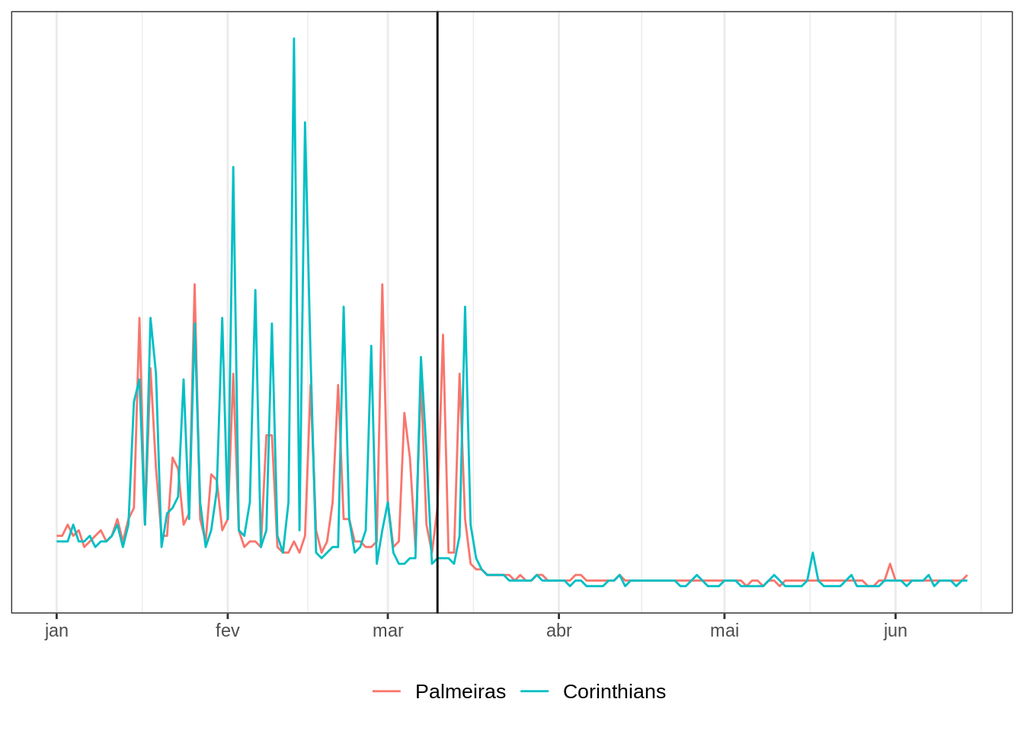

```r
futebol_plot<-plot_trend(keyword_string = c("Palmeiras","Corinthians"))
futebol_plot
```

E como várias pessoas estão em home-office, usando videoconferência, podemos ver como estão as buscas por notebook e as ferramentas zoom, skype e google meet.

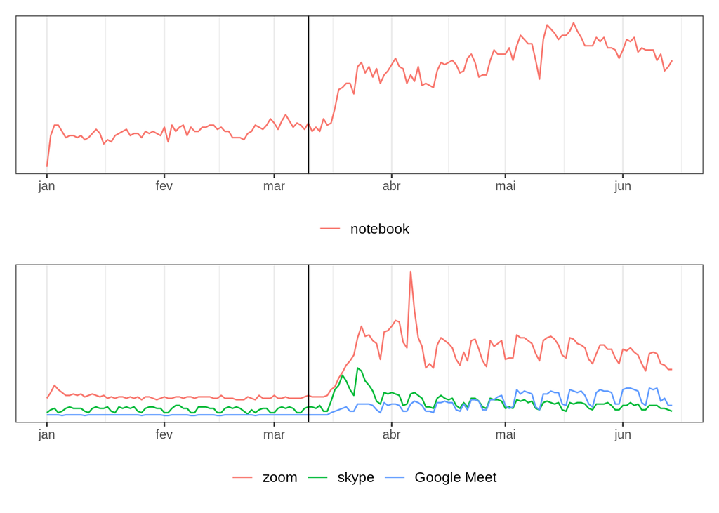

```r
homeoffice_plot<-plot_trend(keyword_string = c("notebook"))
video_plot<-plot_trend(keyword_string = c("zoom","skype","Google Meet"))
(homeoffice_plot)/(video_plot)
```

E será que a procura pelo termo netflix aumentou? Vejamos:

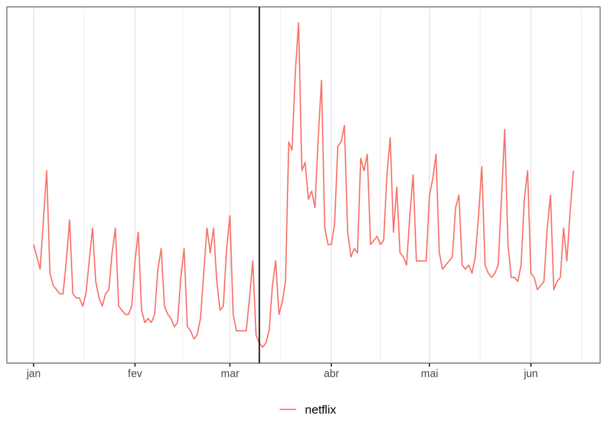

```r
netflix_plot<-plot_trend(keyword_string = c("netflix"))
netflix_plot
```

Aproveitem e qualquer dúvida, postem no fórum de dúvidas. Abraços virtuais Profa. Andreza